# Lecture 5: Hypothesis testing

Economics 527: Econometric Methods

Vadim Marmer, UBC

# Hypotheses and errors

## Estimator and parameter set

- Normally distributed estimator with known variance $\omega^2$:
  $$\underset{1\times1}{\hat\theta} \sim N\big(\underset{1\times1}{\theta},\ \underset{1\times1}{\omega^2}\big), \qquad \frac{\hat\theta - \theta}{\omega} = Z \sim N(0,1)$$
- Regression example, conditional on $X$:
  $$\theta = \beta_1,\, \hat\theta = \hat\beta_1, \, \omega^2 = \sigma^2 / (X_1^\top M_2 X_1).$$
- Parameter set, for example $\Theta = \mathbb{R}$:
  $$\theta \in \Theta$$
- Two disjoint parts:
  $$\begin{aligned}
  \Theta &= \Theta_0 \cup \Theta_1 \\
  \Theta_0 \cap \Theta_1 &= \emptyset
  \end{aligned}$$
- Null and alternative hypotheses:
  $$H_0 : \theta \in \Theta_0 \qquad \text{vs} \qquad H_1 : \theta \in \Theta_1$$

## Examples of $\Theta_0$ and $\Theta_1$

- Point null, $\Theta = \mathbb{R}$:
  $$\begin{aligned}
  \Theta_0 &= \{0\} \\
  \Theta_1 &= \mathbb{R} \setminus \{0\} \\
  &\Longleftrightarrow\quad H_0 : \theta = 0 \quad \text{vs} \quad H_1 : \theta \neq 0
  \end{aligned}$$
- More generally, for a **known** $\theta_0$:
  $$\begin{aligned}
  \Theta_0 &= \{\theta_0\} \\
  \Theta_1 &= \mathbb{R} \setminus \{\theta_0\} \\
  &\Longleftrightarrow\quad H_0 : \theta = \theta_0 \quad \text{vs} \quad H_1 : \theta \neq \theta_0
  \end{aligned}$$
- One-sided null:
  $$\begin{aligned}
  \Theta_0 &= [\,\theta_0,\ +\infty) \\
  \Theta_1 &= (-\infty,\ \theta_0) \\
  &\Longleftrightarrow\quad H_0 : \theta \ge \theta_0 \quad \text{vs} \quad H_1 : \theta < \theta_0
  \end{aligned}$$
- **Definition.** Simple hypothesis: a single-point set; otherwise composite:
  $$\Theta_0 = \{\theta_0\} : \ \text{simple}, \qquad \Theta_0 = [\,0,\ +\infty) : \ \text{composite}$$

## Test statistic and decision rule

- Test statistic $T$: a function of the data, random, with range $S$:
  $$\begin{aligned}
  T &\in S \\
  S &= S_A \cup S_R, \qquad S_A \cap S_R = \emptyset
  \end{aligned}$$
- $S_A$: acceptance region; $S_R$: rejection region.
- Decision rule:
  $$\begin{aligned}
  T \in S_A \quad &\Longrightarrow \quad \text{decide in favor of } \theta \in \Theta_0 \qquad (\text{fail to reject } H_0) \\
  T \in S_R \quad &\Longrightarrow \quad \text{decide in favor of } \theta \in \Theta_1 \qquad (\text{reject } H_0)
  \end{aligned}$$

## Type I and Type II errors

Truth against decision:

| Truth | Decision $H_0$ | Decision $H_1$ |
| --- | --- | --- |
| $H_0$ | correct | Type I error |
| $H_1$ | Type II error | correct |

- Probabilities of the errors:
  $$\begin{aligned}
  \mathrm{P}(\text{Type I error}) &= \mathrm{P}(T \in S_R \mid \theta \in \Theta_0) \\
  \mathrm{P}(\text{Type II error}) &= \mathrm{P}(T \notin S_R \mid \theta \in \Theta_1) \\
  &= \mathrm{P}(T \in S_A \mid \theta \in \Theta_1)
  \end{aligned}$$
- To make $\mathrm{P}(\text{Type I error})$ smaller:
  $$\begin{aligned}
  & S_R \downarrow \\
  \Longrightarrow\quad & S_A \uparrow \\
  \Longrightarrow\quad & \mathrm{P}(\text{Type II error}) \uparrow
  \end{aligned}$$
- We can’t make both error probabilities small at the same time.

## Valid test, size, significance level

- **Definition.** Valid test, with $\alpha$ chosen in advance:
  $$\begin{aligned}
  \mathrm{P}(\text{Type I error}) &= \mathrm{P}(\text{falsely deciding in favour of } H_1 \mid H_0 \text{ true}) \\
  &\le \alpha
  \end{aligned}$$
- Composite $\Theta_0$, supremum of the Type I error probabilities:
  $$\sup_{\theta \in \Theta_0} \mathrm{P}(T \in S_R \mid \theta) \le \alpha$$
- Size $\alpha$ test:
  $$\sup_{\theta \in \Theta_0} \mathrm{P}(T \in S_R \mid \theta) = \alpha$$
- Significance level $\alpha$: small, for example $0.01$, $0.05$, $0.1$.

# Two-sided test

## Point null against a two-sided alternative

- Hypotheses, for example $\theta_0 = 0$:
  $$\underbrace{H_0 : \theta = \theta_0}_{\text{simple}} \qquad \text{vs} \qquad \underbrace{H_1 : \theta \neq \theta_0}_{\text{composite}}$$
- Three objects:
  $$\begin{aligned}
  \theta &: \ \text{true value, unknown, fixed} \\
  \hat\theta &: \ \text{estimator, data, random} \\
  \theta_0 &: \ \text{chosen by you, known, fixed}
  \end{aligned}$$
- Regression example, $\theta = \beta_1$ and $\theta_0 = 0$:
  $$H_0 : \beta_1 = 0 \qquad \text{vs} \qquad H_1 : \beta_1 \neq 0$$

## Test statistic $T(\theta_0)$

- Distance between the data and $H_0$:
  $$T(\theta_0) = \left|\frac{\hat\theta - \theta_0}{\omega}\right|$$
- Reject $H_0$ when:
  $$\begin{aligned}
  & T(\theta_0) \ \text{ is large} \\
  \Longleftrightarrow\quad & T(\theta_0) > c
  \end{aligned}$$
- Regions, $c > 0$:
  $$\begin{aligned}
  S_R &= (c,\ +\infty) \\
  S_A &= [\,0,\ c\,] \\
  S &= S_A \cup S_R = [\,0,\ +\infty)
  \end{aligned}$$
- Choose $c$ for size control:
  $$\mathrm{P}(\text{Type I error}) \le \alpha$$

## Choice of $c$

- Size $\alpha$: set the Type I error probability at $\theta = \theta_0$ to $\alpha$:
  $$\begin{aligned}
  \alpha &= \mathrm{P}(\text{Type I error}) \\
  &= \mathrm{P}(\text{reject } H_0 \mid H_0 \text{ true}) \\
  &= \mathrm{P}\big(T(\theta_0) > c \mid \theta = \theta_0\big) \\
  &= \mathrm{P}\Big(\Big|\frac{\hat\theta - \theta_0}{\omega}\Big| > c \;\Big|\; \theta = \theta_0\Big) \\
  &\overset{\theta = \theta_0}{=} \mathrm{P}\Big(\Big|\underbrace{\frac{\hat\theta - \theta}{\omega}}_{=\,Z \sim N(0,1)}\Big| > c\Big) \\
  &= \mathrm{P}(|Z| > c) \\
  &= \mathrm{P}\big(\underbrace{\{Z > c\}}_{A} \ \text{ or } \ \underbrace{\{-Z > c\}}_{B}\big) \\
  &= \mathrm{P}(Z > c) + \mathrm{P}(Z < -c) \\
  &= 2\,\mathrm{P}(Z > c) \\
  \Longrightarrow\quad \mathrm{P}(Z > c) &= \frac{\alpha}{2} \\
  \Longrightarrow\quad \mathrm{P}(Z \le c) &= 1 - \frac{\alpha}{2} \\
  \Longrightarrow\quad c &= z_{1-\alpha/2} \qquad \big(\mathrm{P}(Z \le z_\tau) = \tau\big)
  \end{aligned}$$

## Size $\alpha$ two-sided test

- Size $\alpha$ test of $H_0 : \theta = \theta_0$ against $H_1 : \theta \neq \theta_0$:
  $$\boxed{\ \text{Reject } H_0 \ \text{ if } \ \left|\frac{\hat\theta - \theta_0}{\omega}\right| > z_{1-\alpha/2}\ }$$
- For $\alpha = 0.05$:
  $$\begin{aligned}
  & z_{0.975} \approx 1.96 \approx 2 \\
  \Longrightarrow\quad & \text{reject if } \ \Big|\frac{\hat\theta - \theta_0}{\omega}\Big| \gtrsim 2 \\
  \Longleftrightarrow\quad & \text{reject if } \ |\hat\theta - \theta_0| \gtrsim 2\,\underbrace{\omega}_{\text{std. dev.}}
  \end{aligned}$$
- Compare with: Reject if $|\hat\theta - \theta_0| > 5\,\omega$:
  $$\mathrm{P}(Z > 5) \approx 3 \cdot 10^{-7}, \qquad \alpha = \mathrm{P}(|Z| > 5) \approx 6 \cdot 10^{-7}$$

## Significance at level $\alpha$

- **Definition.** Significance at level $\alpha$, by a size $\alpha$ test:
  $$\begin{aligned}
  \Big|\frac{\hat\theta}{\omega}\Big| > z_{1-\alpha/2}
  \quad&\Longrightarrow\quad H_0 : \theta = 0 \ \text{ rejected in favour of } \ H_1 : \theta \neq 0 \\
  &\Longrightarrow\quad \hat\theta \ \text{ significant at level } \alpha
  \end{aligned}$$

## Test and confidence interval

- Solve for $\theta_0$:
  $$\begin{aligned}
  H_0 \text{ rejected}
  \quad&\Longleftrightarrow\quad \left|\frac{\hat\theta - \theta_0}{\omega}\right| > z_{1-\alpha/2} \\
  H_0 \text{ not rejected}
  \quad&\Longleftrightarrow\quad \left|\frac{\hat\theta - \theta_0}{\omega}\right| \le z_{1-\alpha/2} \\
  &\Longleftrightarrow\quad -z_{1-\alpha/2} \le \frac{\hat\theta - \theta_0}{\omega} \le z_{1-\alpha/2} \\
  &\Longleftrightarrow\quad -z_{1-\alpha/2}\,\omega \le \hat\theta - \theta_0 \le z_{1-\alpha/2}\,\omega \\
  &\Longleftrightarrow\quad z_{1-\alpha/2}\,\omega \ge \theta_0 - \hat\theta \ge -z_{1-\alpha/2}\,\omega \\
  &\Longleftrightarrow\quad \hat\theta + z_{1-\alpha/2}\,\omega \ge \theta_0 \ge \hat\theta - z_{1-\alpha/2}\,\omega \\
  &\Longleftrightarrow\quad \hat\theta - z_{1-\alpha/2}\,\omega \le \theta_0 \le \hat\theta + z_{1-\alpha/2}\,\omega \\
  &\Longleftrightarrow\quad \theta_0 \in CI_{1-\alpha} = \big[\hat\theta - z_{1-\alpha/2}\,\omega,\ \hat\theta + z_{1-\alpha/2}\,\omega\big]
  \end{aligned}$$
- Equivalent statement of the test:
  $$\boxed{\ \text{Reject } H_0 : \theta = \theta_0 \ \text{ if } \ \theta_0 \notin CI_{1-\alpha}\ }$$

## $CI_{1-\alpha}$ as a set of null values

- All $\theta_0$ the test does not reject:
  $$\begin{aligned}
  CI_{1-\alpha} &= \big\{\theta_0 : T(\theta_0) \le z_{1-\alpha/2}\big\} \\
  &= \Big\{\theta_0 : \Big|\frac{\hat\theta - \theta_0}{\omega}\Big| \le z_{1-\alpha/2}\Big\} \\
  &= \big\{\theta_0 : \text{a size } \alpha \text{ test does not reject } H_0 : \theta = \theta_0\big\}
  \end{aligned}$$
- Suppose in your data:
  $$CI_{0.95} = [\,0.04,\ 0.06\,]$$

# Power

## Noise and signal

- Type II error:
  $$\mathrm{P}(\text{Type II error}) = \mathrm{P}(\text{fail to reject } H_0 \mid \theta \neq \theta_0)$$
- Split $(\hat\theta - \theta_0)/\omega$, under the true $\theta$:
  $$\begin{aligned}
  \underbrace{\frac{\hat\theta - \theta_0}{\omega}}_{\text{data} \,-\, H_0}
  &= \underbrace{\frac{\hat\theta - \theta}{\omega}}_{=\,Z \sim N(0,1),\ \text{noise}}
  + \underbrace{\frac{\theta - \theta_0}{\omega}}_{\text{truth} \,-\, H_0,\ \text{signal}} \\
  &= Z + \frac{\theta - \theta_0}{\omega} \\
  &\sim N\Big(\frac{\theta - \theta_0}{\omega},\ 1\Big)
  \end{aligned}$$

## Power function $\pi(\theta)$

- Probability of rejecting $H_0$, as a function of the true $\theta$:
  $$\begin{aligned}
  \pi(\theta) &= \mathrm{P}(\text{reject } H_0 \mid \theta) \\
  &= \mathrm{P}\Big(\Big|\frac{\hat\theta - \theta_0}{\omega}\Big| > z_{1-\alpha/2} \;\Big|\; \theta\Big) \\
  &= \mathrm{P}\Big(\Big|\frac{\hat\theta - \theta}{\omega} + \frac{\theta - \theta_0}{\omega}\Big| > z_{1-\alpha/2} \;\Big|\; \theta\Big) \\
  &= \mathrm{P}\Big(\Big|\underbrace{Z}_{N(0,1)} + \frac{\theta - \theta_0}{\omega}\Big| > z_{1-\alpha/2}\Big)
  \end{aligned}$$
- Known: $\theta_0$, $\omega$, $z_{1-\alpha/2}$, the distribution of $Z$.
- Unknown: $\theta \in \mathbb{R}$.

## Type II error probability

- Type II error probability depends on $\theta$: For $\theta \neq \theta_0$,
  $$\begin{aligned}
  \mathrm{P}(\text{Type II error} \mid \theta)
  &= \mathrm{P}(\text{fail to reject } H_0 \mid \theta) \\
  &= 1-\mathrm{P}(\text{reject } H_0 \mid \theta) \\
  &= 1 - \pi(\theta).
  \end{aligned}$$

## Distribution of $(\hat\theta - \theta_0)/\omega$ under $H_0$ and $H_1$

- Density of $(\hat\theta - \theta_0)/\omega$, with $\theta_0 < \theta_1 < \theta_2$:

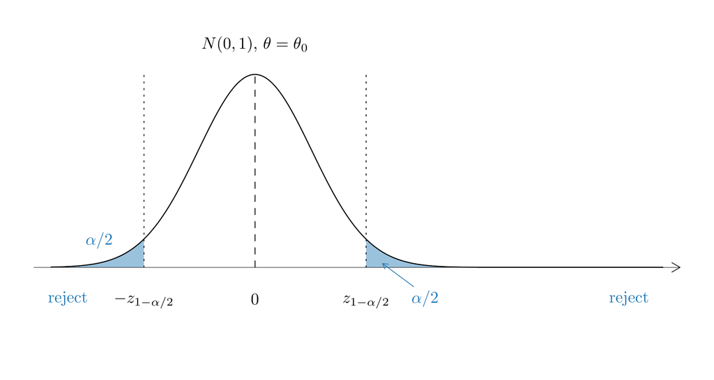

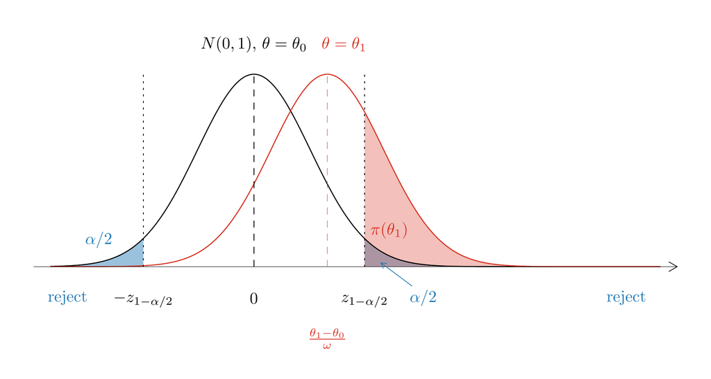

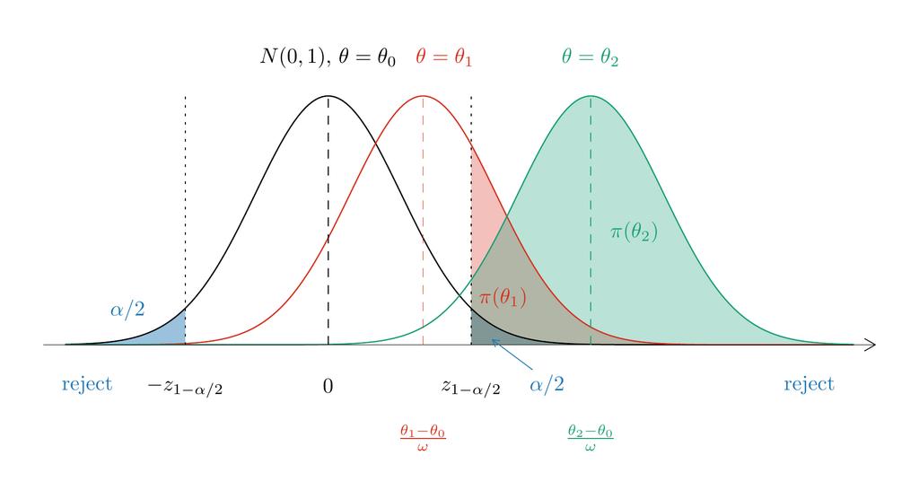

- Under $\theta \neq \theta_0$, more mass in the rejection region:
  $$\mathrm{P}\Big(\Big|\frac{\hat\theta - \theta_0}{\omega}\Big| > z_{1-\alpha/2} \;\Big|\; \theta\Big) > \alpha$$

## Power curve

- $\pi(\theta)$ against $\theta$: minimum $\alpha$ at $\theta_0$, approaches $1$ far from $\theta_0$:

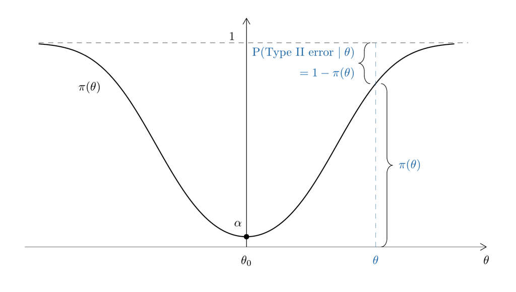

- Largest Type II error probability, as $\theta \to \theta_0$:
  $$\begin{aligned}
  \sup_{\theta \neq \theta_0} \mathrm{P}(\text{Type II error} \mid \theta)
  &= \sup_{\theta \neq \theta_0} \mathrm{P}\Big(\Big|\frac{\hat\theta - \theta_0}{\omega}\Big| \le z_{1-\alpha/2} \;\Big|\; \theta\Big) \\
  &= \sup_{\theta \neq \theta_0} \mathrm{P}\Big(\Big|Z + \frac{\theta - \theta_0}{\omega}\Big| \le z_{1-\alpha/2}\Big) \\
  &= 1 - \alpha
  \end{aligned}$$

## Maximum against supremum

- Closed interval:
  $$\max_{x \in [0,1]} x = 1$$
- Half-open interval:
  $$\begin{aligned}
  \max_{x \in [0,1)} x \ &\ \text{does not exist} \\
  \sup_{x \in [0,1)} x \ &= 1
  \end{aligned}$$

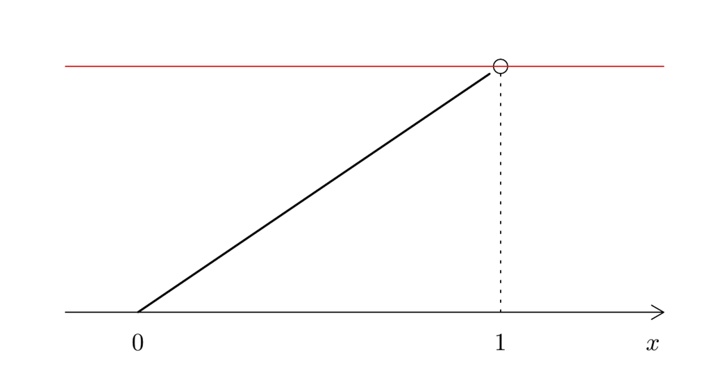

- **Definition.** Supremum:
  $$\sup_{x \in \mathcal{X}} f(x) = \text{smallest upper bound of } \{f(x) : x \in \mathcal{X}\}$$
- $\mathrm{P}(\text{Type II error} \mid \theta)$ over $\theta \neq \theta_0$: no maximum.

## Example: $\hat\theta \sim N(\theta,\ 9)$

- $H_0 : \theta = 0$ vs $H_1 : \theta \neq 0$, $\alpha = 0.05$, $\omega = 3$:
  $$\text{Reject } H_0 \ \text{ if } \ \Big|\frac{\hat\theta}{3}\Big| > 1.96$$
- Power function:
  $$\begin{aligned}
  \pi(\theta) &= \mathrm{P}\Big(\Big|\frac{\hat\theta}{3}\Big| > 1.96 \;\Big|\; \theta\Big) \\
  &= \mathrm{P}\Big(\Big|\frac{\hat\theta - \theta}{3} + \frac{\theta}{3}\Big| > 1.96\Big) \\
  &= \mathrm{P}\Big(\Big|Z + \frac{\theta}{3}\Big| > 1.96\Big) \\
  &= \mathrm{P}\Big(Z + \frac{\theta}{3} > 1.96 \ \text{ or } \ Z + \frac{\theta}{3} < -1.96\Big) \\
  &= \mathrm{P}\Big(Z > 1.96 - \frac{\theta}{3}\Big) + \mathrm{P}\Big(Z < -1.96 - \frac{\theta}{3}\Big)
  \end{aligned}$$

## Example, power at $\theta = 3$

- Substitute $\theta = 3$:
  $$\begin{aligned}
  \pi(3) &= \mathrm{P}\Big(Z > 1.96 - \frac{3}{3}\Big) + \mathrm{P}\Big(Z < -1.96 - \frac{3}{3}\Big) \\
  &= \mathrm{P}(Z > 0.96) + \mathrm{P}(Z < -2.96) \\
  &\approx \underbrace{\mathrm{P}(Z \le -0.96)}_{\approx\,0.16853} + 0.00154 \\
  &\approx 0.17
  \end{aligned}$$
- $\pi(\theta)$ at four values of $\theta$:
  $$\pi(\theta) \approx \begin{cases} 0.063 & \theta = -1 \\ 0.05 & \theta = 0 \\ 0.063 & \theta = 1 \\ 0.17 & \theta = 3 \end{cases}$$

## Failing to reject $\beta_1 = 0$

- Regression, $\theta = \beta_1$, $\omega^2 = \sigma^2 / (X_1^\top M_2 X_1)$:
  $$Y = \beta_1 X_1 + X_2 \beta_2 + U, \qquad H_0 : \beta_1 = 0 \quad \text{vs} \quad H_1 : \beta_1 \neq 0$$
- Suppose $H_0$ is not rejected:
  $$\Big|\frac{\hat\beta_1}{\omega}\Big| \le z_{1-\alpha/2}
  \qquad \overset{?}{\Longrightarrow} \qquad \beta_1 = 0$$
- Type II error probability near $1 - \alpha$ for $\theta$ near $\theta_0$.
- $T(\theta_0) > z_{1-\alpha/2}$: strong evidence that $\theta \neq \theta_0$.
- **Claim.** $T(\theta_0) \le z_{1-\alpha/2}$: not strong evidence in favour of $\theta_0$.

## Minimum detectable deviation

- Detectable $\theta$: $\pi(\theta) \ge \beta$, for example $\beta = 0.85$ or $0.5$.
- Smallest detectable $\bar\theta > \theta_0$ solves:
  $$\mathrm{P}\Big(\Big|Z + \frac{\bar\theta - \theta_0}{\omega}\Big| > z_{1-\alpha/2}\Big) = \beta,
  \qquad \theta_0,\ \omega,\ z_{1-\alpha/2},\ \beta \ \text{ known}$$
- $|\bar\theta - \theta_0|$: the minimum detectable deviation.

## More precise estimator, more power

- Smaller variance:
  $$\begin{aligned}
  \hat\theta^* &\sim N(\theta,\ \omega_*^2) \\
  \omega_*^2 &< \omega^2 \\
  \Longrightarrow\quad \omega_* &< \omega
  \end{aligned}$$
- Both tests valid:
  $$\underbrace{\Big|\frac{\hat\theta - \theta_0}{\omega}\Big| > z_{1-\alpha/2}}_{\text{test with } \hat\theta}
  \qquad \text{or} \qquad
  \underbrace{\Big|\frac{\hat\theta^* - \theta_0}{\omega_*}\Big| > z_{1-\alpha/2}}_{\text{test with } \hat\theta^*}$$
- Suppose $\theta > \theta_0$, larger signal with $\hat\theta^*$:
  $$\begin{aligned}
  \frac{\hat\theta - \theta_0}{\omega} &= Z + \frac{\theta - \theta_0}{\omega} \sim N\Big(\frac{\theta - \theta_0}{\omega},\ 1\Big) \\
  \frac{\hat\theta^* - \theta_0}{\omega_*} &\sim N\Big(\frac{\theta - \theta_0}{\omega_*},\ 1\Big) \\
  \omega_* < \omega \quad &\Longrightarrow\quad \frac{\theta - \theta_0}{\omega} < \frac{\theta - \theta_0}{\omega_*}
  \end{aligned}$$
- Power functions:
  $$\begin{aligned}
  \pi(\theta) &= \mathrm{P}\Big(\Big|\frac{\hat\theta - \theta_0}{\omega}\Big| > z_{1-\alpha/2} \;\Big|\; \theta\Big) \\
  \pi^*(\theta) &= \mathrm{P}\Big(\Big|\frac{\hat\theta^* - \theta_0}{\omega_*}\Big| > z_{1-\alpha/2} \;\Big|\; \theta\Big)
  \end{aligned}$$
- Test with $\hat\theta^*$: more powerful, $\pi^*(\theta) \ge \pi(\theta)$.

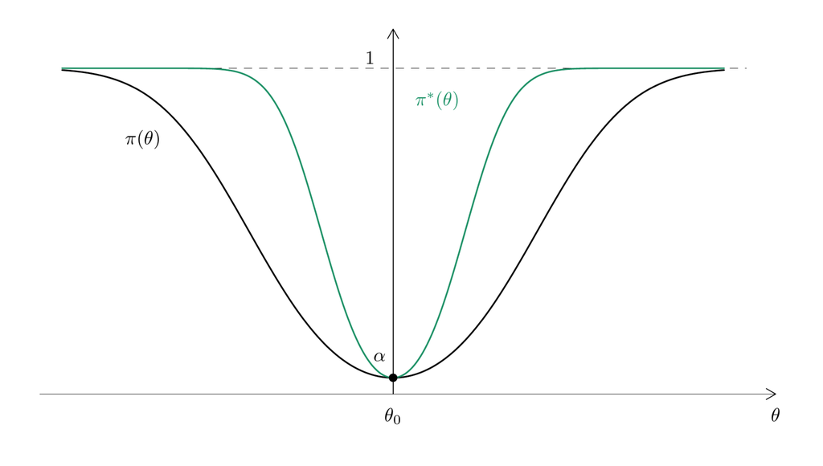

## Test that ignores the data

- $V \sim \text{Uniform}(0,1)$, density and CDF:
  $$\begin{aligned}
  f(v) &= \mathbf{1}\{0 < v < 1\} \\
  &= \begin{cases} 1 & 0 < v < 1 \\ 0 & \text{otherwise} \end{cases} \\
  F(v) &= \begin{cases} 0 & v \le 0 \\ v & 0 < v < 1 \\ 1 & v \ge 1 \end{cases}
  \end{aligned}$$
- For $0 < x < 1$:
  $$\begin{aligned}
  \mathrm{P}(V < x) &= \mathrm{P}(V \le x) \qquad (\text{continuous}) \\
  &= F(x) \\
  &= \int_0^x f(v)\, dv \\
  &= \int_0^x 1 \, dv \\
  &= x
  \end{aligned}$$
- Test:
  1. Throw $\hat\theta$ away.
  2. Draw $V \sim \text{Uniform}(0,1)$.
  3. Reject $H_0 : \theta = \theta_0$ if $V < \alpha$.
- $V$ does not depend on $\theta$:
  $$\begin{aligned}
  \mathrm{P}(\text{Type I error} \mid \theta = \theta_0) &= \mathrm{P}(V < \alpha) \\
  &= \alpha \\
  \tilde\pi(\theta) &= \mathrm{P}(\text{reject } H_0 \mid \theta) \\
  &= \mathrm{P}(V < \alpha) \\
  &= \alpha \qquad \text{for every } \theta
  \end{aligned}$$
- Power $\alpha$: trivial.

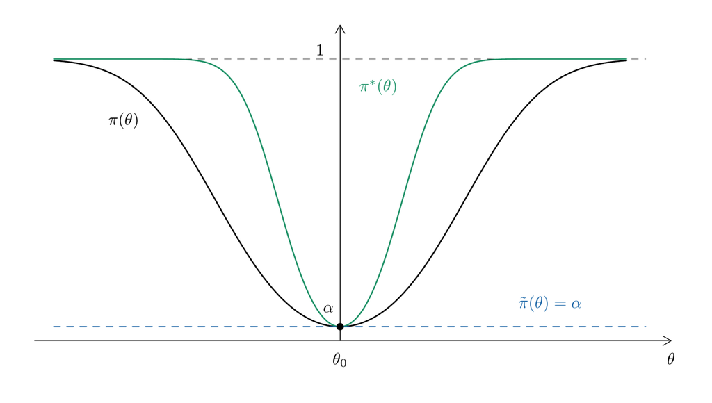

# One-sided tests

## One-sided hypotheses

- One-sided null and alternative, for example $\theta_0 = 0$:
  $$\underbrace{H_0 : \theta \le \theta_0}_{\text{composite}} \qquad \text{vs} \qquad \underbrace{H_1 : \theta > \theta_0}_{\text{composite}}$$
- Test: reject $H_0$ in favour of $H_1$ if:
  $$\frac{\hat\theta - \theta_0}{\omega} > c$$
- Type I error probability for each $\theta \in \Theta_0$, and its supremum:
  $$\begin{aligned}
  \mathrm{P}(\text{Type I error} \mid \theta) &= \mathrm{P}\Big(\frac{\hat\theta - \theta_0}{\omega} > c \;\Big|\; \theta\Big), \qquad \theta \le \theta_0 \\
  \sup_{\theta \le \theta_0} \mathrm{P}(\text{Type I error} \mid \theta) &\le \alpha
  \end{aligned}$$
- Split $(\hat\theta - \theta_0)/\omega$:
  $$\frac{\hat\theta - \theta_0}{\omega} = \underbrace{\frac{\hat\theta - \theta}{\omega}}_{=\,Z} + \underbrace{\frac{\theta - \theta_0}{\omega}}_{\le\, 0 \ \text{ for } \theta \le \theta_0}$$

## Choice of $c$, one-sided

- Supremum over $\Theta_0$, attained at $\theta = \theta_0$:
  $$\begin{aligned}
  \alpha &= \sup_{\theta \le \theta_0} \mathrm{P}(\text{Type I error} \mid \theta) \\
  &= \sup_{\theta \le \theta_0} \mathrm{P}(\text{reject } H_0 \mid \theta) \\
  &= \sup_{\theta \le \theta_0} \mathrm{P}\Big(\frac{\hat\theta - \theta_0}{\omega} > c \;\Big|\; \theta\Big) \\
  &= \sup_{\theta \le \theta_0} \mathrm{P}\Big(\underbrace{\frac{\hat\theta - \theta}{\omega}}_{=\,Z \sim N(0,1)} + \frac{\theta - \theta_0}{\omega} > c \;\Big|\; \theta\Big) \\
  &= \sup_{\theta \le \theta_0} \mathrm{P}\Big(Z + \underbrace{\frac{\theta - \theta_0}{\omega}}_{\le\,0,\ \text{largest at } \theta = \theta_0} > c\Big) \\
  &= \mathrm{P}(Z > c) \\
  \Longrightarrow\quad \mathrm{P}(Z \le c) &= 1 - \alpha \\
  \Longrightarrow\quad c &= z_{1-\alpha}
  \end{aligned}$$

## One-sided test and interval

- Size $\alpha$ test of $H_0 : \theta \le \theta_0$ against $H_1 : \theta > \theta_0$:
  $$\boxed{\ \text{Reject } H_0 \ \text{ if } \ \frac{\hat\theta - \theta_0}{\omega} > z_{1-\alpha}\ }$$
- One-sided interval, all $\theta_0$ the test does not reject:
  $$\begin{aligned}
  CI^{1}_{1-\alpha} &= \Big\{\theta_0 : \frac{\hat\theta - \theta_0}{\omega} \le z_{1-\alpha}\Big\} \\
  &= \big\{\theta_0 : \theta_0 \ge \hat\theta - z_{1-\alpha}\,\omega\big\} \\
  &= \big[\hat\theta - z_{1-\alpha}\,\omega,\ +\infty\big)
  \end{aligned}$$

## Mirror case: $H_0 : \theta \ge \theta_0$

- Reject $H_0 : \theta \ge \theta_0$ in favour of $H_1 : \theta < \theta_0$ if, for some $c > 0$:
  $$\frac{\hat\theta - \theta_0}{\omega} < -c$$
- Choose $c$ from the supremum over $\theta \ge \theta_0$:
  $$\begin{aligned}
  \alpha &\ge \mathrm{P}(\text{Type I error} \mid \theta) \qquad (\theta \ge \theta_0) \\
  &= \mathrm{P}\Big(\frac{\hat\theta - \theta_0}{\omega} < -c \;\Big|\; \theta\Big) \\
  &= \mathrm{P}\Big(Z + \frac{\theta - \theta_0}{\omega} < -c\Big) \\
  \alpha &= \sup_{\theta \ge \theta_0} \mathrm{P}\Big(Z + \underbrace{\frac{\theta - \theta_0}{\omega}}_{\ge\,0} < -c\Big) \qquad (\text{size } \alpha) \\
  &= \mathrm{P}(Z < -c) \qquad (\theta = \theta_0) \\
  \Longrightarrow\quad -c &= z_{\alpha} \\
  \Longrightarrow\quad c &= z_{1-\alpha}
  \end{aligned}$$
- Test:
  $$\boxed{\ \text{Reject } H_0 : \theta \ge \theta_0 \ \text{ if } \ \frac{\hat\theta - \theta_0}{\omega} < -z_{1-\alpha}\ }$$

## Power through $\Phi$

- $\Phi(x) = \mathrm{P}(Z \le x)$, the CDF of $N(0,1)$.
- Left-tailed test of $H_0 : \theta \ge \theta_0$:
  $$\begin{aligned}
  \pi(\theta) &= \mathrm{P}\Big(\frac{\hat\theta - \theta_0}{\omega} < -z_{1-\alpha} \;\Big|\; \theta\Big) \\
  &= \mathrm{P}\Big(Z + \frac{\theta - \theta_0}{\omega} < -z_{1-\alpha}\Big) \\
  &= \mathrm{P}\Big(Z < -z_{1-\alpha} - \frac{\theta - \theta_0}{\omega}\Big) \\
  &= \Phi\Big(\frac{\theta_0 - \theta}{\omega} - z_{1-\alpha}\Big)
  \end{aligned}$$

## Two tests for $H_0 : \theta = \theta_0$

- Against $H_1 : \theta \neq \theta_0$, both of size $\alpha$:
  $$\begin{aligned}
  \text{Test 1 (one-sided)} &: \quad \text{reject } H_0 \ \text{ if } \ \frac{\hat\theta - \theta_0}{\omega} > z_{1-\alpha} \\
  \text{Test 2 (two-sided)} &: \quad \text{reject } H_0 \ \text{ if } \ \Big|\frac{\hat\theta - \theta_0}{\omega}\Big| > z_{1-\alpha/2}
  \end{aligned}$$
- Type I error of Test 1:
  $$\begin{aligned}
  \mathrm{P}(\text{Type I error of Test 1}) &= \mathrm{P}\Big(\frac{\hat\theta - \theta_0}{\omega} > z_{1-\alpha} \;\Big|\; \theta = \theta_0\Big) \\
  &\overset{\theta = \theta_0}{=} \mathrm{P}\Big(\frac{\hat\theta - \theta}{\omega} > z_{1-\alpha}\Big) \\
  &= \mathrm{P}(Z > z_{1-\alpha}) \\
  &= \alpha
  \end{aligned}$$
- Critical values:
  $$\begin{aligned}
  z_{1-\alpha} &< z_{1-\alpha/2} \\
  \Longrightarrow\quad -z_{1-\alpha/2} &< -z_{1-\alpha}
  \end{aligned}$$

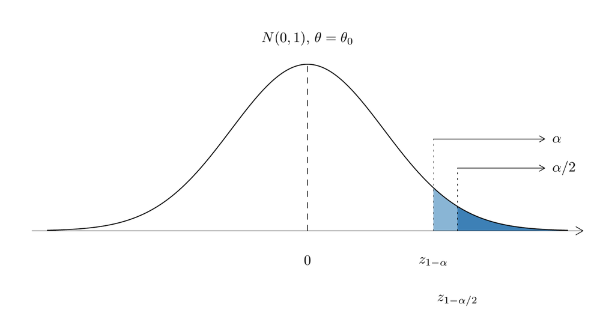

## Power of Test 1 and Test 2

- Power of Test 1:
  $$\begin{aligned}
  \pi_1(\theta) &= \mathrm{P}\Big(\frac{\hat\theta - \theta_0}{\omega} > z_{1-\alpha} \;\Big|\; \theta\Big) \\
  &= \mathrm{P}\Big(Z + \frac{\theta - \theta_0}{\omega} > z_{1-\alpha}\Big)
  \end{aligned}$$
- Power of Test 2:
  $$\begin{aligned}
  \pi_2(\theta) &= \mathrm{P}\Big(\Big|\frac{\hat\theta - \theta_0}{\omega}\Big| > z_{1-\alpha/2} \;\Big|\; \theta\Big) \\
  &= \mathrm{P}\Big(\Big|Z + \frac{\theta - \theta_0}{\omega}\Big| > z_{1-\alpha/2}\Big) \\
  &= \mathrm{P}\Big(Z + \frac{\theta - \theta_0}{\omega} < -z_{1-\alpha/2}\Big) + \mathrm{P}\Big(Z + \frac{\theta - \theta_0}{\omega} > z_{1-\alpha/2}\Big)
  \end{aligned}$$

## One-sided against two-sided power

- $\pi_1(\theta)$ increasing, $\pi_2(\theta)$ U-shaped:

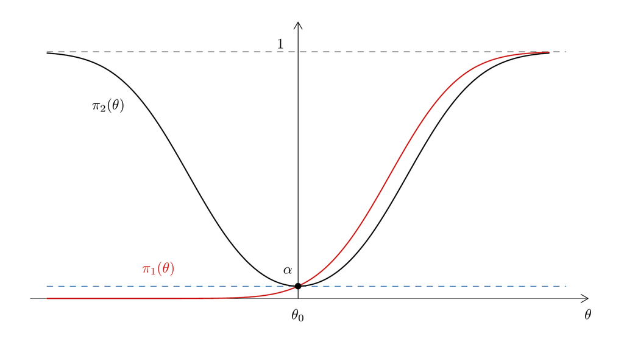

- For $\theta > \theta_0$, Test 1 is more powerful; compare the right tails:
  $$\begin{aligned}
  \Big|\frac{\hat\theta - \theta_0}{\omega}\Big| &= \frac{\hat\theta - \theta_0}{\omega} > z_{1-\alpha/2} \qquad \Big(\frac{\hat\theta - \theta_0}{\omega} > 0\Big) \\
  \Longrightarrow\quad \frac{\hat\theta - \theta_0}{\omega} &> z_{1-\alpha}
  \end{aligned}$$
- For $\theta < \theta_0$, Test 2 is more powerful:
  $$\begin{aligned}
  \frac{\hat\theta - \theta_0}{\omega} &= Z + \underbrace{\frac{\theta - \theta_0}{\omega}}_{<\,0} > z_{1-\alpha} \qquad (\text{Test 1 rejects}) \\
  \pi_1(\theta) &= \mathrm{P}\Big(Z + \frac{\theta - \theta_0}{\omega} > z_{1-\alpha}\Big) \\
  &= \mathrm{P}\Big(Z > z_{1-\alpha} - \frac{\theta - \theta_0}{\omega}\Big) \\
  &< \mathrm{P}(Z > z_{1-\alpha}) \\
  &= \alpha
  \end{aligned}$$
- No uniformly most powerful test against $H_1 : \theta \neq \theta_0$.
- Test 1 biased against $H_1 : \theta \neq \theta_0$.
- Largest Type II error probability of Test 1:
  $$\begin{aligned}
  \text{against } H_1 : \theta > \theta_0 &: \quad \sup_{\theta > \theta_0} \big(1 - \pi_1(\theta)\big) = 1 - \alpha \\
  \text{against } H_1 : \theta \neq \theta_0 &: \quad \sup_{\theta \neq \theta_0} \big(1 - \pi_1(\theta)\big) = 1
  \end{aligned}$$

## Two-sided test with unequal tails

- Test 3 of $H_0 : \theta = \theta_0$ against $H_1 : \theta \neq \theta_0$, reject $H_0$ when:
  $$\frac{\hat\theta - \theta_0}{\omega} > z_{1-\alpha/3} \qquad \text{or} \qquad \frac{\hat\theta - \theta_0}{\omega} < -z_{1-2\alpha/3}$$
- Type I error probability, with $z_\tau = -z_{1-\tau}$:
  $$\begin{aligned}
  \mathrm{P}(\text{Type I error})
  &= \mathrm{P}\Big(\frac{\hat\theta - \theta_0}{\omega} > z_{1-\alpha/3} \ \text{ or } \ \frac{\hat\theta - \theta_0}{\omega} < -z_{1-2\alpha/3} \;\Big|\; \theta = \theta_0\Big) \\
  &= \mathrm{P}\Big(\frac{\hat\theta - \theta_0}{\omega} > z_{1-\alpha/3} \;\Big|\; \theta = \theta_0\Big) \\
  &\qquad + \mathrm{P}\Big(\frac{\hat\theta - \theta_0}{\omega} < -z_{1-2\alpha/3} \;\Big|\; \theta = \theta_0\Big) \\
  &\overset{\theta = \theta_0}{=} \mathrm{P}\Big(\frac{\hat\theta - \theta}{\omega} > z_{1-\alpha/3}\Big) + \mathrm{P}\Big(\frac{\hat\theta - \theta}{\omega} < -z_{1-2\alpha/3}\Big) \\
  &= \underbrace{\mathrm{P}(Z > z_{1-\alpha/3})}_{=\,\alpha/3} + \underbrace{\mathrm{P}(Z < -z_{1-2\alpha/3})}_{=\,\mathrm{P}(Z < z_{2\alpha/3})\,=\,2\alpha/3} \\
  &= \alpha
  \end{aligned}$$

## Power with unequal tails

- Power of Test 3:
  $$\begin{aligned}
  \pi_3(\theta) &= \mathrm{P}(\text{reject } H_0 \mid \theta) \\
  &= \mathrm{P}\Big(\frac{\hat\theta - \theta_0}{\omega} > z_{1-\alpha/3} \;\Big|\; \theta\Big) + \mathrm{P}\Big(\frac{\hat\theta - \theta_0}{\omega} < -z_{1-2\alpha/3} \;\Big|\; \theta\Big) \\
  &= \mathrm{P}\Big(Z + \frac{\theta - \theta_0}{\omega} > z_{1-\alpha/3}\Big) + \mathrm{P}\Big(Z + \frac{\theta - \theta_0}{\omega} < -z_{1-2\alpha/3}\Big) \\
  &= \mathrm{P}\Big(Z > z_{1-\alpha/3} - \frac{\theta - \theta_0}{\omega}\Big) + \mathrm{P}\Big(Z < -z_{1-2\alpha/3} - \frac{\theta - \theta_0}{\omega}\Big)
  \end{aligned}$$
- At $\theta = \theta_0$:
  $$\begin{aligned}
  \pi_3(\theta_0) &= \mathrm{P}(Z > z_{1-\alpha/3}) + \mathrm{P}(Z < -z_{1-2\alpha/3}) \\
  &= \frac{\alpha}{3} + \frac{2\alpha}{3} \\
  &= \alpha
  \end{aligned}$$
- For $\theta > \theta_0$, $(\theta - \theta_0)/\omega > 0$:
  $$\pi_3(\theta) = \underbrace{\mathrm{P}\Big(Z > z_{1-\alpha/3} - \frac{\theta - \theta_0}{\omega}\Big)}_{>\,\alpha/3} + \underbrace{\mathrm{P}\Big(Z < -z_{1-2\alpha/3} - \frac{\theta - \theta_0}{\omega}\Big)}_{<\,2\alpha/3}$$
- $\pi_3(\theta)$ against $\pi_2(\theta)$, both $\alpha$ at $\theta_0$:

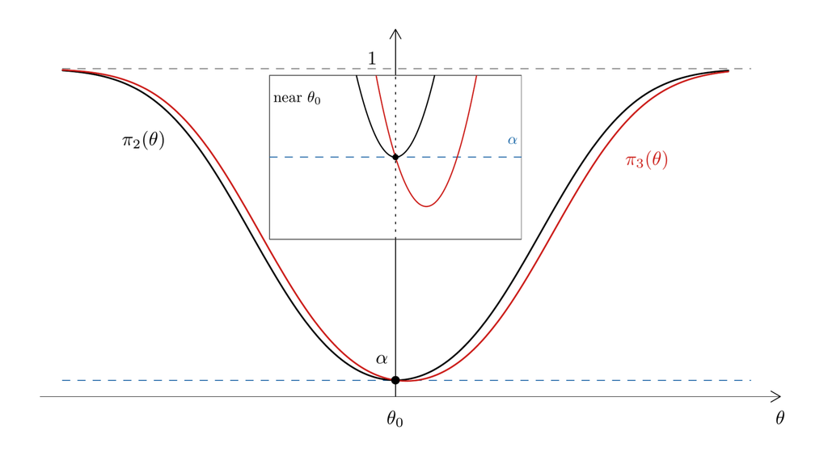

- $\pi_3(\theta) < \alpha$ just right of $\theta_0$: Test 3 biased against $H_1 : \theta \neq \theta_0$.

## Strict inequality in the null

- $H_0 : \theta < \theta_0$ vs $H_1 : \theta \ge \theta_0$, same one-sided test:
  $$\begin{aligned}
  \sup_{\theta < \theta_0} \mathrm{P}\Big(Z + \frac{\theta - \theta_0}{\omega} > z_{1-\alpha}\Big)
  &= \sup_{\theta \in (-\infty,\ \theta_0)} \mathrm{P}\Big(Z + \frac{\theta - \theta_0}{\omega} > z_{1-\alpha}\Big) \\
  &= \mathrm{P}(Z > z_{1-\alpha}) \\
  &= \alpha
  \end{aligned}$$
- $\theta_0 \in \Theta_1$: no power above $\alpha$ at $\theta_0$.

## Null $\theta \neq \theta_0$: not testable

- $H_0 : \theta \neq \theta_0$ vs $H_1 : \theta = \theta_0$; size control:
  $$\sup_{\theta \neq \theta_0} \mathrm{P}(\text{reject } H_0 \mid \theta) \le \alpha$$
- Reject if $|(\hat\theta - \theta_0)/\omega| < c$:
  $$\begin{aligned}
  \alpha &\ge \sup_{\theta \neq \theta_0} \mathrm{P}\Big(\Big|\frac{\hat\theta - \theta_0}{\omega}\Big| < c \;\Big|\; \theta\Big) \\
  &= \sup_{\theta \neq \theta_0} \mathrm{P}\Big(\Big|Z + \frac{\theta - \theta_0}{\omega}\Big| < c\Big) \\
  &= \mathrm{P}\big(|Z| < c\big) \qquad (\theta \to \theta_0) \\
  &= \mathrm{P}(\text{reject } H_0 \mid \theta = \theta_0)
  \end{aligned}$$
- Size $\alpha$: no power above $\alpha$ at $\theta_0$, not testable.

# p-values

## Two-sided p-value

- Under $H_0 : \theta = \theta_0$:
  $$\frac{\hat\theta - \theta_0}{\omega} \sim N(0,1)$$
- Test statistic:
  $$T(\theta_0) = \left|\frac{\hat\theta - \theta_0}{\omega}\right|$$
- Two tails beyond $\pm T(\theta_0)$:

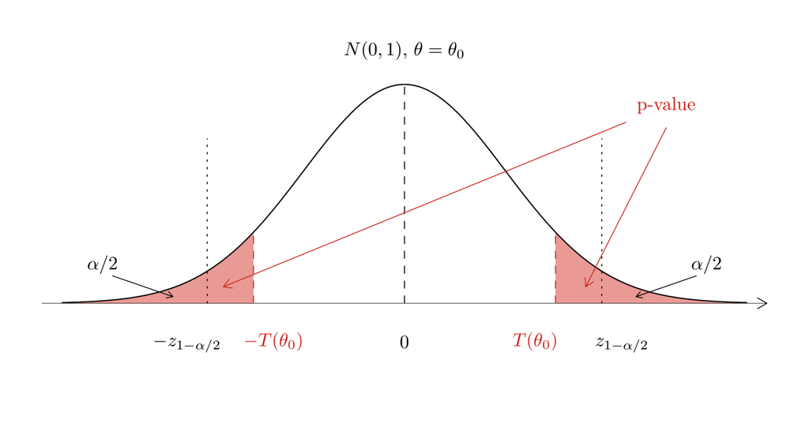

- Test:
  $$\text{Reject } H_0 : \theta = \theta_0 \ \text{ if } \ \text{p-value} < \alpha$$
- p-value:
  $$\begin{aligned}
  \text{p-value} &= \Phi(-T(\theta_0)) + 1 - \Phi(T(\theta_0)) \\
  &= 2\big(1 - \Phi(T(\theta_0))\big) \qquad \big(\Phi(-x) = 1 - \Phi(x)\big) \\
  &= \boxed{\ 2\Big(1 - \Phi\Big(\Big|\frac{\hat\theta - \theta_0}{\omega}\Big|\Big)\Big)\ } \\
  &= 2\,\Phi\Bigl(-\Big|\frac{\hat\theta - \theta_0}{\omega}\Big|\Bigr)
  \end{aligned}$$
- p-value: random before the data are plugged in, a statistic.
- **Claim.** Size $\alpha$:
  $$\mathrm{P}(\text{p-value} < \alpha \mid \theta = \theta_0) = \alpha$$

## Two-sided p-value under $\theta = \theta_0$

- CDF of $U \sim \text{Uniform}(0,1)$, for $t \in (0,1)$:
  $$\mathrm{P}(U \le t) = t$$
- CDF of the p-value, for $t \in (0,1)$:
  $$\begin{aligned}
  \mathrm{P}(\text{p-value} \le t \mid \theta = \theta_0)
  &= \mathrm{P}\Big(2\Big(1 - \Phi\Big(\Big|\underbrace{\frac{\hat\theta - \theta_0}{\omega}}_{=\,Z \sim N(0,1)}\Big|\Big)\Big) \le t \;\Big|\; \theta = \theta_0\Big) \\
  &= \mathrm{P}\big(2(1 - \Phi(|Z|)) \le t\big) \\
  &= \mathrm{P}\Big(1 - \Phi(|Z|) \le \frac{t}{2}\Big) \\
  &= \mathrm{P}\Big(\Phi(|Z|) \ge 1 - \frac{t}{2}\Big) \\
  &= \mathrm{P}\Big(|Z| \ge \Phi^{-1}\Big(1 - \frac{t}{2}\Big)\Big) \\
  &= \mathrm{P}\big(|Z| \ge z_{1-t/2}\big) \\
  &= \mathrm{P}\big(Z \ge z_{1-t/2}\big) + \mathrm{P}\big(Z \le \underbrace{-z_{1-t/2}}_{=\,z_{t/2}}\big) \\
  &= \frac{t}{2} + \frac{t}{2} \\
  &= t
  \end{aligned}$$
- Under $\theta = \theta_0$, for all $t \in (0,1)$:
  $$\begin{aligned}
  & \mathrm{P}(\text{p-value} \le t \mid \theta = \theta_0) = t \\
  \Longrightarrow\quad & \boxed{\ \text{p-value} \sim \text{Uniform}(0,1)\ }
  \end{aligned}$$

## One-sided p-value, right tail

- Right tail beyond $(\hat\theta - \theta_0)/\omega$, for $H_0 : \theta \le \theta_0$:

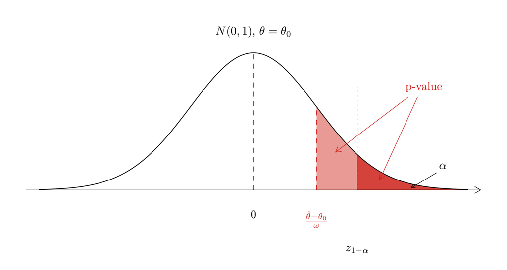

- Right-tailed test:
  $$\boxed{\ \text{p-value} = 1 - \Phi\Big(\frac{\hat\theta - \theta_0}{\omega}\Big)\ }$$
- The same, as a probability over $Z^* \sim N(0,1)$ independent of the data:
  $$\begin{aligned}
  \text{p-value} &= \mathrm{P}^*\Big(Z^* > \frac{\hat\theta - \theta_0}{\omega} \;\Big|\; \hat\theta\Big) \\
  &= 1 - \Phi\Big(\frac{\hat\theta - \theta_0}{\omega}\Big)
  \end{aligned}$$
- Reject $H_0$ if p-value $< \alpha$.
- Same decision as the one-sided test:
  $$\begin{aligned}
  & 1 - \Phi\Big(\frac{\hat\theta - \theta_0}{\omega}\Big) < \alpha \\
  \Longleftrightarrow\quad & \frac{\hat\theta - \theta_0}{\omega} > z_{1-\alpha}
  \end{aligned}$$

## One-sided p-value, left tail

- Left tail below $(\hat\theta - \theta_0)/\omega$, for $H_0 : \theta \ge \theta_0$:

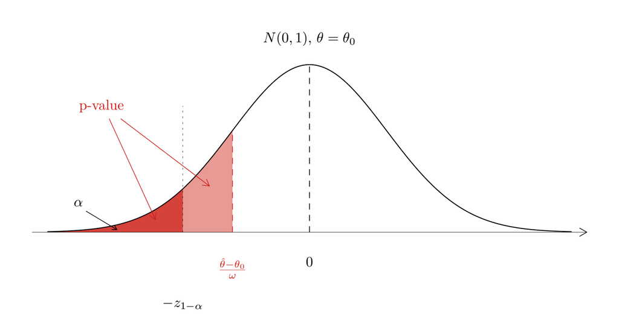

- Left-tailed test: reject if $(\hat\theta - \theta_0)/\omega < -z_{1-\alpha}$.
- p-value:
  $$\boxed{\ \text{p-value} = \Phi\Big(\frac{\hat\theta - \theta_0}{\omega}\Big)\ }$$
- Reject $H_0$ if p-value $< \alpha$.

## Size of the right-tailed p-value test

- We will use: $\Phi^{-1}(1 - \alpha) = z_{1-\alpha}$.
- Supremum over $\Theta_0$, attained at $\theta = \theta_0$:
  $$\begin{aligned}
  \sup_{\theta \le \theta_0} \mathrm{P}(\text{p-value} < \alpha \mid \theta)
  &= \sup_{\theta \le \theta_0} \mathrm{P}\Big(1 - \Phi\Big(\frac{\hat\theta - \theta_0}{\omega}\Big) < \alpha \;\Big|\; \theta\Big) \\
  &= \sup_{\theta \le \theta_0} \mathrm{P}\Big(\Phi\Big(\frac{\hat\theta - \theta_0}{\omega}\Big) > 1 - \alpha \;\Big|\; \theta\Big) \\
  &= \sup_{\theta \le \theta_0} \mathrm{P}\Big(\Phi\Big(Z + \underbrace{\frac{\theta - \theta_0}{\omega}}_{\le\,0}\Big) > 1 - \alpha\Big) \\
  &= \mathrm{P}\big(\Phi(Z) > 1 - \alpha\big) \\
  &= \mathrm{P}\big(Z > \Phi^{-1}(1 - \alpha)\big) \\
  &= \mathrm{P}(Z > z_{1-\alpha}) \\
  &= \alpha
  \end{aligned}$$

## Distribution of $\Phi(Z)$

- New random variable:
  $$W = \Phi(Z), \qquad W \in (\,0, 1\,)$$
- CDF of $W$:
  $$\mathrm{P}(W \le x) = \begin{cases} 0 & x \le 0 \\ ? & 0 < x < 1 \\ 1 & x \ge 1 \end{cases}$$
- We will use: $a \le b \Longleftrightarrow g(a) \le g(b)$ for strictly increasing $g$.
- For $0 < x < 1$, apply $\Phi^{-1}$ inside:
  $$\begin{aligned}
  \mathrm{P}(W \le x) &= \mathrm{P}\big(\Phi(Z) \le x\big) \\
  &= \mathrm{P}\big(\Phi^{-1}(\Phi(Z)) \le \Phi^{-1}(x)\big) \\
  &= \mathrm{P}\big(Z \le \underbrace{\Phi^{-1}(x)}_{=\,z_x}\big) \\
  &= \Phi\big(\Phi^{-1}(x)\big) \\
  &= x
  \end{aligned}$$
- Hence:
  $$\mathrm{P}\big(\Phi(Z) \le x\big) = x \quad\Longrightarrow\quad \boxed{\ \Phi(Z) \sim \text{Uniform}(0,1)\ }$$

## Distribution of $1 - \Phi(Z)$

- CDF of $1 - \Phi(Z)$, for $0 < u < 1$:
  $$\begin{aligned}
  F_{1-W}(u) &= \mathrm{P}(1 - W \le u) \\
  &= \mathrm{P}\big(1 - \Phi(Z) \le u\big) \\
  &= \mathrm{P}\big(\Phi(Z) \ge 1 - u\big) \\
  &= \mathrm{P}\big(Z \ge \Phi^{-1}(1 - u)\big) \\
  &= 1 - \Phi\big(\Phi^{-1}(1 - u)\big) \\
  &= 1 - (1 - u) \\
  &= u
  \end{aligned}$$
- Hence:
  $$\mathrm{P}\big(1 - \Phi(Z) \le u\big) = u \quad\Longrightarrow\quad \boxed{\ 1 - \Phi(Z) \sim \text{Uniform}(0,1)\ }$$

## p-values under $\theta = \theta_0$

- $(\hat\theta - \theta_0)/\omega = Z$:
  $$\begin{aligned}
  1 - \Phi(Z) &\sim \text{Uniform}(0,1) \\
  \Phi(Z) &\sim \text{Uniform}(0,1) \\
  2\big(1 - \Phi(|Z|)\big) &\sim \text{Uniform}(0,1)
  \end{aligned}$$
- $(\hat\theta - \theta_0)/\omega \sim N(0,1)$: critical values $z_{1-\alpha}$, $z_{1-\alpha/2}$ from $N(0,1)$.
- p-value $\sim \text{Uniform}(0,1)$: critical value $\alpha$ from $\text{Uniform}(0,1)$.
- For every p-value:
  $$\begin{aligned}
  \mathrm{P}(\text{p-value} < \alpha \mid \theta = \theta_0) &= \mathrm{P}(\text{p-value} \le \alpha \mid \theta = \theta_0) \\
  &= \text{CDF of the p-value at } \alpha, \ \text{ under } \theta = \theta_0 \\
  &= \mathrm{P}(V \le \alpha), \quad V \sim \text{Uniform}(0,1) \\
  &= \alpha
  \end{aligned}$$
- In general: $X \sim F$, $F$ continuous and strictly increasing $\Longrightarrow F(X) \sim \text{Uniform}(0,1)$.

# Summary

## Hypotheses, errors, size

- $\hat\theta \sim N(\theta, \omega^2)$, $\omega^2$ known; $\theta \in \Theta = \Theta_0 \cup \Theta_1$, $\Theta_0 \cap \Theta_1 = \emptyset$; $H_0 : \theta \in \Theta_0$ vs $H_1 : \theta \in \Theta_1$.
- Test statistic $T \in S = S_A \cup S_R$; reject $H_0$ if $T \in S_R$.
- Type I error: reject a true $H_0$; Type II error: fail to reject a false $H_0$.
- $S_R \downarrow \ \Longrightarrow\ \mathrm{P}(\text{Type I error}) \downarrow \ \Longrightarrow\ \mathrm{P}(\text{Type II error}) \uparrow$.
- Valid test: $\sup_{\theta \in \Theta_0} \mathrm{P}(T \in S_R \mid \theta) \le \alpha$; size $\alpha$ test: equality.

## Two-sided test and power

- Reject $H_0 : \theta = \theta_0$ if $|(\hat\theta - \theta_0)/\omega| > z_{1-\alpha/2}$; at $\alpha = 0.05$, $z_{0.975} \approx 1.96$.
- $|\hat\theta / \omega| > z_{1-\alpha/2}$: $\hat\theta$ significant at level $\alpha$.
- Fail to reject $\Longleftrightarrow \theta_0 \in CI_{1-\alpha}$; $CI_{1-\alpha} = \{\theta_0 : T(\theta_0) \le z_{1-\alpha/2}\}$.
- $(\hat\theta - \theta_0)/\omega = Z + (\theta - \theta_0)/\omega \sim N\big((\theta - \theta_0)/\omega,\ 1\big)$.
- $\pi(\theta) = \mathrm{P}(|Z + (\theta - \theta_0)/\omega| > z_{1-\alpha/2})$, $\pi(\theta_0) = \alpha$.
- $\sup_{\theta \neq \theta_0} \mathrm{P}(\text{Type II error} \mid \theta) = \sup_{\theta \neq \theta_0} \big(1 - \pi(\theta)\big) = 1 - \alpha$.
- Smaller $\omega$: more power.
- Test that ignores the data: size $\alpha$, power $\alpha$.

## One-sided tests and p-values

- $H_0 : \theta \le \theta_0$: reject if $(\hat\theta - \theta_0)/\omega > z_{1-\alpha}$; $z_{1-\alpha} < z_{1-\alpha/2}$.
- $\sup_{\theta \le \theta_0} \mathrm{P}(\text{reject } H_0 \mid \theta)$ attained at $\theta = \theta_0$.
- $CI^{1}_{1-\alpha} = [\hat\theta - z_{1-\alpha}\,\omega,\ +\infty)$.
- Against $H_1 : \theta \neq \theta_0$: one-sided test biased; no uniformly most powerful test.
- Unequal tails, $\alpha/3$ right and $2\alpha/3$ left: size $\alpha$, biased against $H_1 : \theta \neq \theta_0$.
- p-values; reject if p-value $< \alpha$:
  $$\begin{aligned}
  \text{two-sided:}&\ \ 2\big(1 - \Phi(|(\hat\theta - \theta_0)/\omega|)\big) \\
  \text{right-tailed:}&\ \ 1 - \Phi\big((\hat\theta - \theta_0)/\omega\big) \\
  \text{left-tailed:}&\ \ \Phi\big((\hat\theta - \theta_0)/\omega\big)
  \end{aligned}$$
- Under $\theta = \theta_0$: every p-value $\sim \text{Uniform}(0,1)$; $\mathrm{P}(\text{p-value} < \alpha \mid \theta = \theta_0) = \alpha$.